# ENGR 222 Thermodynamics Winter 2021-2022 Lab 2

## CLOSED SYSTEM ENERGY BALANCES

Recall the energy balance equation governed by the 1st Law of Thermodynamics: $$ Q - W = m \Delta u $$ where $ Q $ is the heat transfer into the system, $ W $ is the work done by the system, $ m $ is the mass of the system, and $ \Delta u $ is the change in specific internal energy of the system.

Also, recall that if a process involves any kind of expansion or compression (i.e. one of the system boundaries is moving), we can calculate the boundary work $ W_b $ as: $$ W_b = \int_{1}^{2} PdV $$ where $ P $ is the pressure of the system and $ V $ is the volume of the system.

We will analyze a spring-loaded piston cylinder-like device where water will undergo an expansion process by means of heat addition. A known mass of water was placed into the cylinder, and the temperature and pressure of the system as well as the change in volume (i.e. height change) of the system were measured as heat was added. We can look at how pressure and volume are related throughout the process to determine the boundary work. We can then perform an energy balance on the system to determine the amount of heat added over the course of the process.

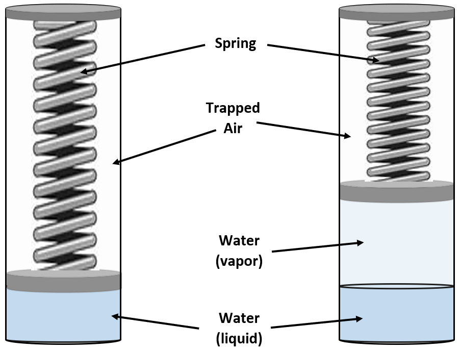

The piston-cylinder shown has two unique features above the piston: a spring and an enclosed mass of trapped air. As the cylinder is heated up (assume only the water is heated up), the water will begin to expand (i.e. vaporize) pushing the piston up. But as the water pushes the piston up, there is increasing resistance from the spring (recall Hooke’s Law for springs) and the air (recall Boyle’s Law and the Ideal Gas Equation).

Using the data given to you (under Lab2 on WeBWorK), you will calculate the boundary work done by the water and the heat absorbed by the water.  
To perform your energy balance, you will need to find the internal energy of the water at the various points where data was collected. Note: Due to measurement error, the pressure in your data will probably not line up with the saturated pressure at the given temperature.

## LAB MEMO FORMAT

You may team up with one classmate (i.e. form a team of 2) to write this lab memo (pick one set of data to use in your report). The lab memo must be computer generated and will be submitted using the link on Moodle. The set up should follow the following format:

#### *Title Page*

Make sure both team members’ names are on the front page. Also put the name of the lab, the course and course section, and the due date.

#### *Results Sections* (see last page for help on how to compute some of the processed data)

In Excel, create a table showing your raw data: piston displacement ($ mm $), temperature ($ ^\circ C $), internal (water) pressure ($ kPa $), and "external" (air) pressure ($ kPa $). Insert this table into your report as a Table (not an image; the data should be editable in Word).

Next show a **separate** table with your processed data: **piston displacement ($ m $)**, **volume ($ m^3 $)**, specific volume ($ \frac{m^3}{kg} $), **absolute internal pressure ($ kPa $)**, **absolute external pressure ($ kPa $)**, **boundary work done by water ($ J $)**, **boundary work done on air ($ J $)**, **work done on spring ($ J $)**, $ \nu_f $ ($ \frac{m^3}{kg} $), $ \nu_g $ ($ \frac{m^3}{kg} $), quality (%), $ u_f $ ($ \frac{kJ}{kg} $), $ u_g $ ($ \frac{kJ}{kg} $), $ u $ ($ \frac{kJ}{kg} $), and **heat added ($ J $)**. Before inserting this table, hide the columns that are not listed in bold font.

Generate a plot (use the area plot; just "area" NOT "stacked area") using the pressure on the y-axis and the volume on the x-axis; make an area plot displaying area generated using the internal pressure values and the area using the external pressures (both areas should be on the same plot). Immediately after the graph in your report, comment on the two areas and briefly explain what each area represents (be specific).

On a single scatter plot, plot the spring work as a function of height. Add a "polynomial" trendline of 2nd order; display the equation on the plot with the intercept set to zero. Immediately after the plot, comment on the curve (How do the coefficients in the equation relate to the spring constant?).

#### *Discussions and Conclusions Sections*

Comment on any discrepancies you might see in the data. Identify possible sources of errors that could have led to these inconsistencies (imagine yourself as the individual collecting the data, do not solely focus on the data processing that you are doing).

#### *Sample Calculation*

Without the use of Excel, show your calculations for data set (but not the initial state or the next row after it): pick one pressure, temperature, and height from your raw data and show the math you used to complete the table with the processed data (i.e., absolute pressure, volume, quality, specific internal energy, etc.). Also show the calculations used to determine the total boundary work and heat absorbed between the previous state and this state. You may neatly write these calculations on white printer paper and scan it into your report or you may use Equation Editor in Word or you may use MathCad. You must include all units.

Be sure to have page numbers (except the title page) and check for spelling and grammar. Also, your tables should be neat and have column headers and units (when appropriate). You should insert your table into your report as a Table that can be edited; do not copy and paste a picture or screenshot of your table into your report. Use the appropriate number of significant figures (usually about 4 or 5 digits, not including the first zeroes for decimal values). Make sure you have axes titles and units in your graphs.

Example tables (many more rows will be shown!) and plots. Note significant digits!

| Height (pist. Disp) $ \left( mm \right) $ | Temperature $ \left( ^\circ C \right) $ | Internal Gauge Pressure $ \left( kPa \right) $ | External Gauge Pressure $ \left( kPa \right) $ |
| --- | --- | --- | --- |
| 0 | 20.91 | -59.09 | -59.19 |
| 5.1 | 80.79 | -52.48 | -53.05 |
| 11.9 | 83.2 | -47.78 | -48.94 |

| Height (pist. Disp) $ \left( m \right) $ | Total Volume $ \left( cm^3 \right) $ | Abs. Internal Pressure $ \left( kPa \right) $ | Abs. External Pressure $ \left( kPa \right) $ | Bound. Work Total by water $ \left( J \right) $ | Bound. Work Total by air $ \left( J \right) $ | Spring Work Total $ \left( J \right) $ | Q Total $ \left( J \right) $ |
| --- | --- | --- | --- | --- | --- | --- | --- |
| 0 | 10 | 42.23 | 42.13 | 0 | 0 | 0 | 0 |
| 0.0051 | 10.99 | 48.84 | 48.27 | 0.0455 | 0.0452 | 0.000334 | 2504.0 |
| 0.0119 | 12.33 | 53.54 | 52.38 | 0.1137 | 0.1123 | 0.001488 | 2608.0 |

[figure not shown]

[figure not shown]

## GRADING RUBRIC

| **Section and Description** | **Point Total** |
| --- | --- |
| **Title Page** | **1** |
| **Results** - Raw data table - Calculated data table - $P$ vs. $V$ area plot - $W$ vs $\Delta h$ graph (with regression equation) | **60** 10 25 15 10 |
| **Discussion/Conclusions** - Comments and identification of sources of error | **9** 9 |
| **Sample Calculation** - Correct equations and values used - Correct units used | **20** 16 4 |
| **Format** - Spelling, grammar, page numbers, professionalism, etc. | **10** 10 |

**Note:** Spelling and grammar mistakes anywhere in the memo may result in point deductions.

## How to compute select columns in the Processed Data table (watch units!)

- Specific volume. Compute it from the volume and mass.
- Boundary work. This is the area under the $ P $ - $ V $ curve from the beginning up to the current data point. (The first row is zero since nothing has happened yet.) To compute each subsequent row, we will assume that the curve is straight from one data point to the next: Multiply the average pressure (of this point and the previous point), by the difference in volume (this gives the work done between these two points). Then add the boundary work from the previous row. This calculation is done the same way for the boundary work of water and of air.
- Work done on spring. **Hint:** The force exerted by the water is balanced by the forces from the air and the spring.
- $ \nu_f $, $ \nu_g $, $ u_f $, $ u_g $. These values must be interpolated from the reference book values above and below your temperature. Notice that the range of temperatures we have are not all in between the same two rows in the reference book.
- Quality. Compute it from $ \nu_f $, $ \nu_g $, and the current value of $ \nu $.
- Internal energy. Compute it from the quality, $ u_f $, and $ u_g $.
- Heat added to the water. Use the First Law as stated in this document. For each row, use the prior data point as the initial state and the current row as the final state. (The first row is zero, since no heat was added yet.) Then add the prior row’s heat to get the total heat added.